# Hands-On Programming with R

# 6. Environments-X

**Environments:**

For example, Figure 8.1 shows part of the file system on my computer. I have tons of folders. Inside one of them is a subfolder named Documents, inside of that subfolder is a sub-subfolder named ggsubplot, inside of that folder is a folder named inst, inside of that is a folder named doc, and inside of that is a file named manual.pdf.

[figure not shown]

R uses a similar system to save R objects. Each object is saved inside of an environment, a list-like object that resembles a folder on your computer. Each environment is connected to a parent environment, a higher-level environment, which creates a hierarchy of environments.

You can see R’s environment system with the parenvs function in the `pryr` package (note parenvs came in the pryr package when this book was first published). `parenvs(all = TRUE)` will return a list of the environments that your R session is using.

```r
library(pryr)
parenvs(all = TRUE)
```

| label | name |
| --- | --- |
|  | "" |
|  | "package:pryr" |
|  | "package:bookdown" |
|  | "package:deal" |
|  | "tools:rstudio" |
|  | "package:stats" |
|  | "package:graphics" |
|  | "package:grDevices" |
|  | "package:utils" |
|  | "package:datasets" |

[output cut: 4 more lines]

[figure not shown]

**Working with Environments:**

R comes with some helper functions that you can use to explore your environment tree.

```r
as.environment("package:stats")
```

```
<environment: package:stats>
attr(,"name")
[1] "package:stats"
attr(,"path")
[1] "C:/Program Files/R/R-3.5.3/library/stats"
```

Three environments in your tree also come with their own accessor functions.

```r
globalenv()
```

```
<environment: R_GlobalEnv>
```

```r
## <environment: R_GlobalEnv>
baseenv()
```

```
<environment: base>
```

```r
## <environment: base>
emptyenv()
```

```
<environment: R_EmptyEnv>
```

```r
##<environment: R_EmptyEnv>
```

Next, you can look up an environment’s parent with parent.env:

```r
parent.env(globalenv())
```

```
<environment: package:pryr>
attr(,"name")
[1] "package:pryr"
attr(,"path")
[1] "C:/Users/cevi herdian/Documents/R/win-library/3.5/pryr"
```

You can view the objects saved in an environment with `ls` or `ls.str`.

```r
ls(globalenv())
```

```
[1] "a"     "b"     "c"     "data"  "deck"  "poker" "stuff"
```

You can use R’s $ syntax to access an object in a specific environment. For example, you can access `deck` from the global environment:

```r
head(globalenv()$deck, 3)
```

|  | face | suit | value |
| --- | --- | --- | --- |
| 1 | king | spades | 13 |
| 2 | queen | spades | 12 |
| 3 | jack | spades | 11 |

And you can use the `assign` function to save an object into a particular environment.

```r
assign("new", "Hello Global", envir = globalenv())
globalenv()$new
```

```
[1] "Hello Global"
```

- The Active Environment

At any moment of time, R is working closely with a single environment. R will store new objects in this environment (if you create any), and R will use this environment as a starting point to look up existing objects (if you call any).

```r
environment()
```

```
<environment: R_GlobalEnv>
```

The global environment plays a special role in R. It is the active environment for every command that you run at the command line. As a result, any object that you create at the command line will be saved in the global environment. You can think of the global environment as your user workspace.

When you call an object at the command line, R will look for it first in the global environment. But what if the object is not there? In that case, R will follow a series of rules to look up the object.

**Scoping Rules:**

R follows a special set of rules to look up objects. These rules are known as R’s scoping rules:

1. R looks for objects in the current active environment.
2. When you work at the command line, the active environment is the global environment. Hence, R looks up objects that you call at the command line in the global environment as in Figure 8.3.

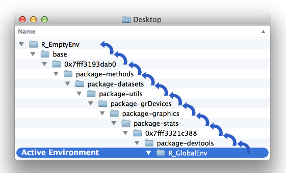

**Assignment:**

When you assign a value to an object, R saves the value in the active environment under the object’s name. If an object with the same name already exists in the active environment, R will overwrite it.

```r
new
```

```
[1] "Hello Global"
```

```r
new <- "Hello Active"
new
```

```
[1] "Hello Active"
```

This arrangement creates a quandary for R whenever R runs a function. Many functions save temporary objects that help them do their jobs.

```r
roll <- function() {
  die <- 1:6
  dice <- sample(die, size = 2, replace = TRUE)
  sum(dice)
}
roll()
```

```
[1] 9
```

**Evaluation:**

R creates a new environment each time it evaluates a function. R will use the new environment as the active environment while it runs the function, and then R will return to the environment that you called the function from, bringing the function’s result with it.

We want to know what the environments look like: what are their parent environments, and what objects do they contain? `show_env` is designed to tell us:

```r
show_env <- function(){
  list(ran.in = environment(),
    parent = parent.env(environment()),
    objects = ls.str(environment()))
}
```

`show_env` is itself a function, so when we call show_env(), R will create a runtime environment to evaluate the function in.

```r
show_env()
```

```
$ran.in
<environment: 0x000000000a0831e0>

$parent
<environment: R_GlobalEnv>

$objects
```

This time show_env ran in a new environment, 0x000000000a0831e0

# ==Project 3: Slot Machine==

# 7. Programs-X

The following function generates three symbols from a group of common slot machine symbols

```r
get_symbols <- function() {
  wheel <- c("DD", "7", "BBB", "BB", "B", "C", "0")
  sample(wheel, size = 3, replace = TRUE,
    prob = c(0.03, 0.03, 0.06, 0.1, 0.25, 0.01, 0.52))
}
```

```r
get_symbols()
```

```
[1] "0"   "0"   "BBB"
```

`get_symbols` uses the probabilities observed in a group of video lottery terminals from Manitoba, Canada. The Manitoba slot machines use the complicated payout scheme shown in `Table 9.1.` A player will win a prize if he gets:

1. Three of the same type of symbol (except for three zeroes)
2. Three bars (of mixed variety)
3. One or more cherries

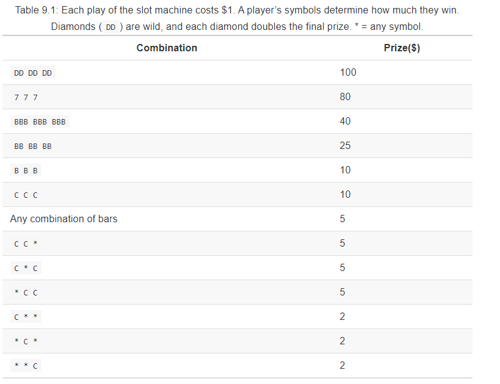

- Sequential Steps

To have R execute steps in sequence, place the steps one after another in an R script or function body. See Figure 9.1

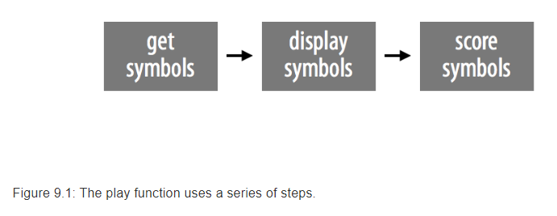

- Parallel Cases

Another way to divide a task is to spot groups of similar cases within the task. Some tasks require different algorithms for different groups of input. If you can identify those groups, you can work out their algorithms one at a time. See Figure 9.2 and Figure 9.3

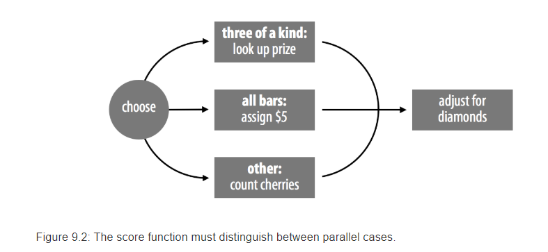

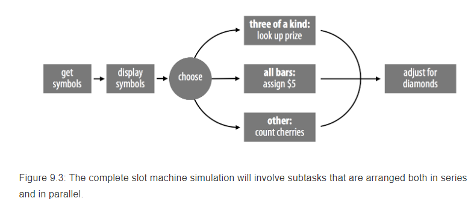

**if Statements:**

An `if` statement tells R to do a certain task for a certain case. In English you would say something like, “If this is true, do that.” In R, you would say:

```r
# if (this) {
#   that
# }
```

```r
x <- 1
if (3 == 3) {
  x <- 2
}
x
```

```
[1] 2
```

**else Statements:**

```r
# if (this) {
#   Plan A
# } else {
#   Plan B
# }
```

```r
a <- 1
b <- 1
if (a > b) {
  print("A wins!")
} else if (a < b) {
  print("B wins!")
} else {
  print("Tie.")
}
```

```
[1] "Tie."
```

```r
# if ( # Case 1: all the same <1>) {
#   prize <- # look up the prize <3>
# } else if ( # Case 2: all bars <2> ) {
#   prize <- # assign $5 <4>
# } else {
#   # count cherries <5>
#   prize <- # calculate a prize <7>
# }
```

If you like, you can reorganize your flow chart around these tasks, as in Figure 9.4. The chart will describe the same strategy, but in a more precise way. I’ll use a diamond shape to symbolize an if else decision. See Figure 9-4.

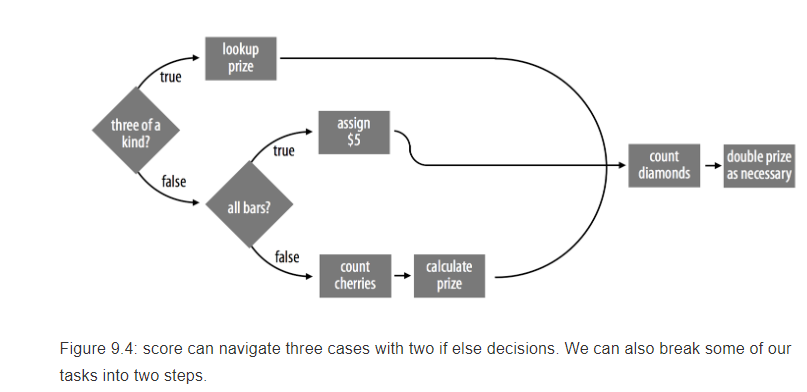

**Lookup Tables:**

Very often in R, the simplest way to do something will involve subsetting. How could you use subsetting here? Since you know the exact relationship between the symbols and their prizes, you can create a vector that captures this information.

```r
payouts <- c("DD" = 100, "7" = 80, "BBB" = 40, "BB" = 25,
  "B" = 10, "C" = 10, "0" = 0)
payouts
```

```
 DD   7 BBB  BB   B   C   0
100  80  40  25  10  10   0
```

Now you can extract the correct prize for any symbol by subsetting the vector with the symbol’s name:

```r
payouts["DD"]
```

```
 DD
100
```

```r
payouts["B"]
```

```
 B
10
```

If you want to leave behind the symbol’s name when subsetting, you can run the `unname` function on the output:

```r
unname(payouts["DD"])
```

```
[1] 100
```

`unname` returns a copy of an object with the names attribute removed.

`payouts` is a type of lookup table, an R object that you can use to look up values. Subsetting payouts provides a simple way to find the prize for a symbol. It doesn’t take many lines of code, and it does the same amount of work whether your symbol is `DD` or `0`.

Sadly, our method is not quite automatic; we need to tell R which symbol to look up in ``payouts`

```r
symbols <- c("7", "7", "7")
symbols[1]
```

```
[1] "7"
```

```r
## "7"
payouts[symbols[1]]
```

```
 7
80
```

```r
##  7
## 80
symbols <- c("C", "C", "C")
payouts[symbols[1]]
```

```
 C
10
```

```r
##  C
## 10
```

You don’t need to know the exact symbol to look up because you can tell R to look up whichever symbol happens to be in `symbols`.

# 8. S3-X

# 9. Loops-X

# 10. Speed-X

# Appendix

## A. Installing R and Rstudio

You’ll go from downloading R to opening your first R session. Both R and RStudio are free and easy to download (Open Source).

**How to Download and Install R:**

R is maintained by an international team of developers who make the language available through the web page of The Comprehensive R Archive Network. The top of the web page provides three links for downloading R. Follow the link that describes your operating system: Windows, Mac, or Linux. https://cran.r-project.org/

- Windows/ Mac/ Linux

To install R on Windows/Mac/Linux, click the “Download R for Windows” link. Then click the “base” link. Next, click the first link at the top of the new page.

- 32-bit Versus 64-bit

64-bit R uses 64-bit memory pointers, and 32-bit R uses 32-bit memory pointers. This means 64-bit R has a larger memory space to use (and search through). The terms 32-bit and 64-bit refer to the way a computer’s processor (also called a CPU), handles information. The 64-bit version of Windows handles large amounts of random access memory (RAM) more effectively than a 32-bit system. Source: https://support.microsoft.com/en-us/help/15056/windows-7-32-64-bit-faq

**Using R:**

R isn’t a program that you can open and start using, like Microsoft Word or Internet Explorer. Instead, R is a computer language, like C, C++, or UNIX. Now almost everyone uses R with an application called RStudio IDE (Integrated Development).

Windows and Mac users usually do not program from a terminal window, so the Windows and Mac downloads for R come with a simple program that opens a terminal-like window for you to run R code in. You may hear people refer to them as the Windows or Mac R GUIs (Grafics User Interfaces.

When you open RStudio, a window appears with three panes in it, as in `Figure A-1`.vThe largest pane is a console window. This is where you’ll run your R code and see results. The console window is exactly what you’d see if you ran R from a UNIX console or the Windows or Mac GUIs.

[figure not shown]

**RStudio:**

RStudio is an application like Microsoft Word-except that instead of helping you write in English, RStudio helps you write in R.

**Getting started R Programming:**

Now that you have both R and RStudio on your computer, you can begin using R by opening the RStudio program. Open RStudio just as you would any program, by clicking on its icon or by typing “RStudio” at the Windows Run prompt.

## B. R Packages

- Many of R’s most useful functions do not come preloaded when you start R, but reside in packages that can be installed on top of R.
- R packages are similar to libraries in C, C ++, and Javascript, packages in Python, and gems in Ruby. An R package bundles together useful functions, help files, and data sets. You can use these functions within your own R code once you load the package they live in.

R packages will let you take advantage of R’s most useful features:

- its large community of package writers (many of whom are active data scientists)
- and its prewritten routines for handling many common (and exotic) data-science tasks

> Base R: It is just the collection of R functions that gets loaded every time you start R. These functions provide the basics of the language, and you don’t have to load a package before you can use them.

**Installing Packages:**

The easiest way to install an R package is with the `install.packages` R function. `install.packages("package name")`

This will search for the specified package in the collection of packages hosted on the CRAN site. When R finds the package, it will download it into a libraries folder on your computer. R can access the package here in future R sessions without reinstalling it.

You can install multiple packages at once by linking their names with R’s concatenate function, `c`. For example, to install the `ggplot2`, `reshape2`, and `dplyr` packages, run:

`install.packages(c("ggplot2", "reshape2", "dplyr"))`

**Loading Packages:**

Installing a package doesn’t immediately place its functions at your fingertips. It just places them on your computer. To use an R package, you next have to load it in your R session with the command:

`library(package name)`

Library will make all of the package’s functions, data sets, and help files available to you until you close your current R session. The next time you begin an R session, you’ll have to reload the package with library if you want to use it, but you won’t have to reinstall it.

You only have to install each package once. After that, a copy of the package will live in your R library. To see which packages you currently have in your R library, run:

`library()`

`library()` also shows the path to your actual R library, which is the folder that contains your R packages. You may notice many packages that you don’t remember installing. This is because R automatically downloads a set of useful packages when you first install R.

Install packages from (almost) anywhere The devtools R package makes it easy to install packages from locations other than the CRAN website. devtools provides functions like

- install_github
- install_gitorious
- install_bitbucket
- in stall_url

These work similar to install.packages, but they search new locations for R packages. `install_github` is especially useful because many R developers provide development versions of their packages on GitHub. The development version of a package will contain a sneak peek of new functions and patches but may not be as stable or as bug free as the CRAN version.

Why does R make you bother with installing and loading packages?

- If every packed load-> very large and slow program
- It is simpler to only install and load the packages that you want to use when you want to use them.
- It is possible to update your copy of an R package without updating your entire copy of R.

What’s the best way to learn about R packages?

- The R-packages mailing list is a place to start.: https://stat.ethz.ch/mailman/listinfo/r-packages
- Blogs: www.r-bloggers.com
- RStudio: http://support.rstudio.com.
- CRAN groups packages by subject area: https://cran.r-project.org/web/views/

## C. Updating R and Its Packages

The R Core Development Team continuously hones the R language by catching bugs, improving performance, and updating R to work with new technologies. The easiest way to stay current with R is to periodically check the CRAN website: https://cran.r-project.org

RStudio also constantly improves its product. You can acquire the newest updates just by downloading them from RStudio.

- R Packages

Package authors occasionally release new versions of their packages to add functions, fix bugs, or improve performance. `update.packages(c("ggplot2", "reshape2", "dplyr"))`

## D. Loading and Saving Data in R

- Data Sets in Base R

Import `deck`.

```r
deck
```

These data sets are not very interesting, but they give you a chance to test code or make a point without having to load a data set from outside R. You can see a list of R’s data sets as well as a short description of each by running: `help(package = "datasets")`

```r
help(package = "datasets")
```

To use a data set, just type its name. Each data set is already presaved as an R object. For example: iris (Edgar Anderson’s Iris Data)

```r
iris
```

- Working Directory

Each time you open R, it links itself to a directory on your computer, which R calls the working directory. This is where R will look for files when you attempt to load them, and it is where R will save files when you save them.

To determine which directory R is using as your working directory, run: `getwd()`

```r
getwd()
```

You can place data files straight into the folder that is your working directory, or you can move your working directory to where your data files are. You can move your working directory to any folder on your computer with the function `setwd()`

You can also change your working directory by clicking on Session > Set Working Directory > Choose Directory in the RStudio menu bar.

You can see what files are in your working directory with list.files().

```r
list.files()
```

- Plain-text Files

Plain-text files are one of the most common ways to save data. They are very simple and can be read by many different computer programs-even the most basic text editors. For this reason, public data often comes as plain-text files.

All plain-text files can be saved with the extension .txt (for text), but sometimes a file will receive a special extension that advertises how it separates data-cell entries. Since entries in the data set mentioned earlier are separated with a comma, this file would be a comma-separated-values file and would usually be saved with the extension .csv.

- read.table

```r
poker <- read.table("deck.csv", sep = ",", header = TRUE)
```

More about read.table, see the documentation https://www.rdocumentation.org/packages/utils/versions/3.5.3/topics/read.table sep: Use sep to tell read.table what character your file uses to separate data entries.

header: Use header to tell read.table whether the first line of the file contains variable names instead of values.

na.strings: Oftentimes data sets will use special symbols to represent missing information. If you know that your data uses a certain symbol to represent missing entries, you can tell read.table (and the preceding functions) what the symbol is with the na.strings argument.

Skip and nrow: Use skip to tell R to skip a specific number of lines before it starts reading in values from the file. Use nrow to tell R to stop reading in values after it has read in a certain number of lines.

stringsAsFactors: Setting the argument stringsAsFactors to FALSE will ensure that R saves any character strings in your data set as character strings, not factors.

If you will be loading more than one data file, you can change the default factoring behavior at the global level with: `options(stringsAsFactors = FALSE)`

Or

You can use Import Dataset from toolbar Environment -From Text -From Excel etc.

**The read Family:**

R also comes with some prepackaged short cuts for read.table, shown in Table D-1.

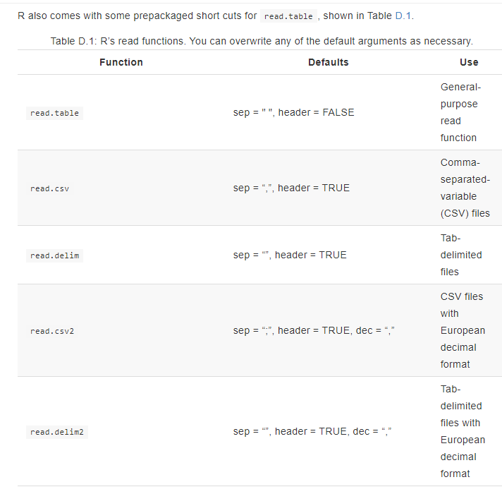

‘read.delim2’ and ‘read.csv2’ exist for European R users. These functions tell R that the data uses a comma instead of a period to denote decimal places. (If you’re wondering how this works with CSV files, CSV2 files usually separate cells with a semicolon, not a comma.)

- read.fwf

One type of plain-text file defies the pattern by using its layout to separate data cells. Each row is placed in its own line (as with other plain-text files), and then each column begins at a specific number of characters from the lefthand side of the document.

You can read fixed-width files into R with the function read.fwf. The function takes the same arguments as read.table but requires an additional argument, widths, which should be a vector of numbers. Each ith entry of the widths vector should state the width (in characters) of the ith column of the data set. `poker <- read.fwf("poker.fwf", widths = c(10, 7, 6), header = TRUE)`

- HTML Links

You can pass a web address into the file name argument for any of R’s data-reading functions. `poker <- read.csv("http://.../poker.csv")`

Note that websites that begin with **https://** are secure websites, which means R may not be able to access the data provided at these links.

** Saving Plain-Text Files: **

Once your data is in R, you can save it to any file format that R supports. The three basic write functions appear in Table D-2.

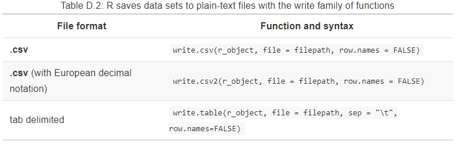

Use write.csv to save your data as a .csv file and write.table to save your data as a tab delimited document or a document with more exotic separators. `write.csv(poker, "data/poker.csv", row.names = FALSE)`

- Compressing Files

To compress a plain-text file, surround the file name or file path with the function bzfile, gzfile, or xzfile. For example: `write.csv(poker, file = bzfile("data/poker.csv.bz2"), row.names = FALSE)`

Each of these functions will compress the output with a different type of compression format, shown in Table D-3.

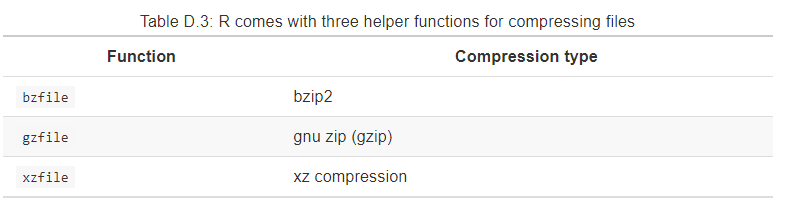

- R Files

R provides two file formats of its own for storing data, `.RDS` and `.RData`. RDS files can store a single R object, and RData files can store multiple R objects.

You can open a RDS file with readRDS. For example, if the royal flush data was saved as poker.RDS, you could open it with: `poker <- readRDS("poker.RDS")`

Opening RData files is even easier. Simply run the function load with the file: `load("file.RData")`

Both readRDS and load take a file path as their first argument, just like R’s other read and write functions. If your file is in your working directory, the file path will be the file name.

- Saving R Files

For example, if you have three R objects, a, b, and c, you could save them all in the same RData file and then reload them in another R session:

```r
a <- 1
b <- 2
c <- 3
data<-c(a,b,c)
save(data, file = "stuff.RData")
load("stuff.RData")
```

```r
stuff<-load("stuff.RData")
```

```r
stuff
data
```

Saving your data as an R file offers some advantages over saving your data as a plaintext file. R automatically compresses the file and will also save any R-related metadata associated with your object. This can be handy if your data contains factors, dates and times, or class attributes. You won’t have to reparse this information into R the way you would if you converted everything to a text file.

On the other hand, R files cannot be read by many other programs, which makes them inefficient for sharing. They may also create a problem for long-term storage if you don’t think you’ll have a copy of R when you reopen the files.

**Excel Spreadsheets:**

Microsoft Excel is a popular spreadsheet program that has become almost industry standard in the business world. There is a good chance that you will need to work with an Excel spreadsheet in R at least once in your career. You can read spreadsheets into R and also save R data as a spreadsheet in a variety of ways.

- Export from Excel

The best method for moving data from Excel to R is to export the spreadsheet from Excel as a .csv or .txt file. Not only will R be able to read the text file, so will any other data analysis software. Text files are the lingua franca of data storage.

To export data from Excel, open the Excel spreadsheet and then go to Save As in the Microsoft Office Button menu. Then choose CSV in the Save as type box that appears and save the files. You can then read the file into R with the read.csv function.

- Copy and Paste

You can also copy portions of an Excel spreadsheet and paste them into R. To do this, open the spreadsheet and select the cells you wish to read into R. Then select Edit > Copy in the menu bar-or use a keyboard shortcut-to copy the cells to your clipboard. On most operating systems, you can read the data stored in your clipboard into R with: `read.table("clipboard")`

- XLConnect

Many packages have been written to help you read Excel files directly into R. Unfortunately, many of these packages do not work on all operating systems. Others have been made out of date by the .xlsx file format. One package that does work on all file systems (and gets good reviews) is the XLConnect package. To use it, you’ll need to install and load the package: `install.packages("XLConnect")`

- Reading Spreadsheets

You can use XLConnect to read in an Excel spreadsheet with either a one- or a two-step process.

`wb <- loadWorkbook("file.xlsx")`

`sheet1 <- readWorksheet(wb, sheet = 1, startRow = 0, startCol = 0, endRow = 100, endCol = 3)`

You can combine these two steps with readWorksheetFromFile. It takes the file argument from loadWorkbook and combines it with the arguments from readWorksheet. You can use it to read one or more sheets straight from an Excel file:

`sheet1 <- readWorksheetFromFile("file.xlsx", sheet = 1, startRow = 0, startCol = 0, endRow = 100, endCol = 3)`

- Writing Spreadsheets

Writing to an Excel spreadsheet is a four-step process:

1. `b <- loadWorkbook("file.xlsx", create = TRUE)`
2. `createSheet(wb, "Sheet 1")`
3. `writeWorksheet(wb, data = poker, sheet = "Sheet 1")`
4. `writeWorksheetToFile("file.xlsx", data = poker, sheet = "Sheet 1", startRow = 1, startCol = 1)`

**Loading Files from Other Programs:**

You should follow the same advice I gave you for Excel files whenever you wish to work with file formats native to other programs: open the file in the original program and export the data as a plain-text file, usually a CSV. This will ensure the most faithful transcription of the data in the file, and it will usually give you the most options for customizing how the data is transcribed.

- Connecting to Databases

Working with a database will require experience that goes beyond the skill set of a typical R user. However, if you are interested in doing this, the best place to start is by downloading these R packages and reading their documentation. Use the DBI package to connect to databases through individual drivers.

For MySQL use RMySQL, for SQLite use RSQLite, for Oracle use ROracle, for PostgreSQL use RPostgreSQL, and for databases that use drivers based on the Java Database Connectivity (JDBC) API use RJDBC. Once you have loaded the appropriate driver package, you can use the commands provided by DBI to access your database.

# Change log update

- 19.01.2019
- 13.04.2019
- 14.04.2019
- 15.04.2019
- 16.04.2019
- 17.04.2019

# Preferences

- [Hands-On Programming with R](https://rstudio-education.github.io/hopr/)

# License

MIT